# Semester 4 Coding Portfolio Part 3: Time Series Part A: Estimation, Inference & Forecasting with ARMA

This notebook covers the following topics:

- Exploring time-series data
- Inference and forecasting

This notebook is expected to take around 20 hours to complete:

- 4 hours for the formative part
- 6 hours of self-study on the topics covered by this notebook
- 10 hours for the summative part of this notebook

Like all notebooks in this portfolio, it is split into two sections:

- Formative
- Summative

**Formative section**  
Simply complete the given functions! You may ask for help from fellow students and TAs on this section, and solutions might be provided later on.

**Summative section**  
In this section, you are asked to do original work with little guidance, based on the skills you learned in the formative part (as well as lectures and workshops). This section is graded not just on passing automated tests, but also on quality, originality, and effort (see assessment criteria in the assignment description).

```python
# TODO: Please enter your student number here
STUDENT_NUMBER = 14806762
```

# Formative Section

Please do not add additional cells to this section, and do not delete given code. Simply fill out the code or answer questions in the given cells.

```python
# load some useful libraries

import statsmodels
import pandas as pd
import numpy as np
import matplotlib.pyplot as plt
from matplotlib.ticker import FuncFormatter
import statsmodels.api as sm
from statsmodels.tsa.arima.model import ARIMA
from statsmodels.tsa.stattools import adfuller, acf, pacf
import warnings
warnings.filterwarnings("ignore")
```

#### Part 1: Cleaning and Exploring the Covid-19 Data

```python
# Load the COVID-19 dataset
df = pd.read_csv('sem4_portfolio_3_data.csv')

display(df.head())
```

|  | target_variable | target_end_date | location | location_name | temporal_resolution | population | geo_type | geo_value | abbreviation | full_location_name | ... | type | forecast_value | truth_source | truth_value | abs_error | forecast_week | target_week | model_type | model_type.general | abs_error_per10k.pop |
| --- | --- | --- | --- | --- | --- | --- | --- | --- | --- | --- | --- | --- | --- | --- | --- | --- | --- | --- | --- | --- | --- |
| 0 | inc case | 2020-04-11 | 01 | Alabama | wk | 4903185 | state | al | AL | Alabama | ... | point | 920.0 | Observed Data (NYTimes) | 1630 | 710.0 | 1 | 2 | parametric-time.series-RW.first.difference | parametric-time.series | 1.448038 |
| 1 | inc case | 2020-04-11 | 02 | Alaska | wk | 731545 | state | ak | AK | Alaska | ... | point | 86.0 | Observed Data (NYTimes) | 86 | 0.0 | 1 | 2 | parametric-time.series-RW.first.difference | parametric-time.series | 0.000000 |
| 2 | inc case | 2020-04-11 | 04 | Arizona | wk | 7278717 | state | az | AZ | Arizona | ... | point | 1414.0 | Observed Data (NYTimes) | 1374 | 40.0 | 1 | 2 | parametric-time.series-RW.first.difference | parametric-time.series | 0.054955 |
| 3 | inc case | 2020-04-11 | 05 | Arkansas | wk | 3017804 | state | ar | AR | Arkansas | ... | point | 334.0 | Observed Data (NYTimes) | 485 | 151.0 | 1 | 2 | parametric-time.series-RW.first.difference | parametric-time.series | 0.500364 |
| 4 | inc case | 2020-04-11 | 06 | California | wk | 39512223 | state | ca | CA | California | ... | point | 7742.0 | Observed Data (NYTimes) | 8625 | 883.0 | 1 | 2 | parametric-time.series-RW.first.difference | parametric-time.series | 0.223475 |

5 rows × 23 columns

#### a) Load the data, filtering the dataset to focus exclusively on incident cases in the whole of the US. Ensure there are no duplicate rows in the resulting dataset. Plot the time series of cases.

```python
df = df[df['target_variable'] == 'inc case']
df = df[df['abbreviation'] == 'US']
df = df[['target_end_date','truth_value']].drop_duplicates()

display(df.head())
```

|  | target_end_date | truth_value |
| --- | --- | --- |
| 55 | 2020-04-11 | 218581 |
| 166 | 2020-04-18 | 201156 |
| 333 | 2020-04-25 | 211999 |
| 556 | 2020-05-02 | 194939 |
| 780 | 2020-05-09 | 177311 |

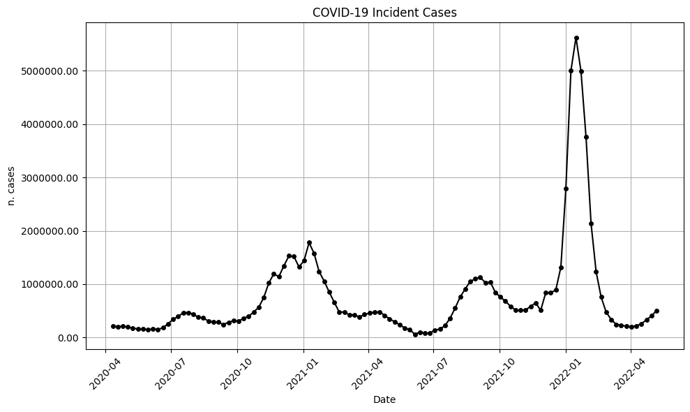

```python
# Convert the 'target_end_date' column to datetime format
df['target_end_date'] = pd.to_datetime(df['target_end_date'])

# TODO 1: Plot the time series data

#. Your solution here ...

plt.figure(figsize=(10, 6))
plt.plot(df['target_end_date'], df['truth_value'], marker='o', linestyle='-', color='black',markersize = '4')
plt.title('COVID-19 Incident Cases')
plt.xlabel('Date')
plt.ylabel('n. cases')
plt.grid(True)
# Manually format y-axis labels to avoid scientific notation
plt.gca().yaxis.set_major_formatter(FuncFormatter(lambda x, _: '{:.2f}'.format(x)))
plt.xticks(rotation=45)
plt.tight_layout()
plt.show()
```